# rapport

# Projet

Dans cette partie nous allons traiter du projet 2. Il consiste à simuler un système complexe et avec un composant réparable.

## Question 2

Nous allons maintenant simuler l’état du système. On considérera que les composantes du système suivent des lois de Weibull de paramètre $\lambda = 5$ et $\beta = 5$.

La trajectoire du système est :

g2 <- df %>% ggplot() + geom_line(aes(x = t, y = systeme, col = num_systeme)) + facet_grid(num_systeme ~ .) g2

[figure not shown]

En fixant les paramètres à $\lambda = 5$ et $\beta = 5$, le premier système a une durée de vie de t = 3,8, le deuxième de t = 4 et le troisième de t = 4.8.

```
## [1] 3.93306
```

```
## [1] 3.919898 3.946222
```

On estime le temps de vie moyen de notre système à 3,933. Son intervalle de confiance à 95% est $[3,920;3.946]$.

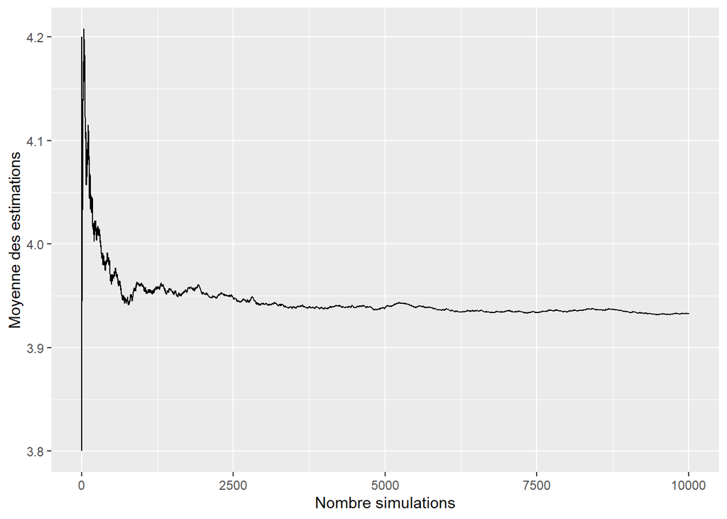

## Question 3

Le composant critique que nous avons choisis est le composant $x_6$. En effet, il est un composant critique car il est en série avec tout le reste du système et donc une panne de ce composant entraine forcément une panne du système. Nous allons maintenant implémenter le fait que ce composant soit réparable. On part du principe qu’un technicien vient tous les intervalles de temps $\delta$ pour le réparer : si le composant est en panne, il le répare, sinon il ne fait rien. Dans les deux cas, le déplacement du technicien implique un coût.

Nous allons tracer quelques trajectoire de l’état notre nouveau système réparable. Cette fois-ci, on fixe $\lambda = 15$ et $\beta = 3$.

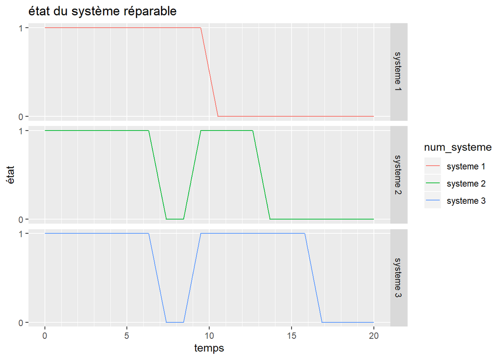

Nous allons maintenant regarder avec quel intervalle de temps $\delta$ il faut demander au technicien d’intervenir pour que le système soit le plus rentable possible. La fonction de récompense est la suivante :
$$R(\delta) = a \mathbb{E}(T) - C \mathbb{E}(N)$$
. Le coefficients $a$ correspond au gain du système associé au temps, et le coefficient $C$ correspond au coût d’intervention du technicien. $N$ est le nombre moyen d’intervention du technicien avant l’instant T de panne du système.

On implémente cette fonction, puis on cherche à la maximiser par rapport à $\delta$. Comme précédemment les valeurs de $\mathbb{E}(T)$ et $\mathbb{E}(N)$ sont estimées par la loi des grands nombres.

Pour la maximisation, on va fixer reprendre les paramètres utilisés précédemment : on fixe $\lambda = 15$, $\beta = 3$. Pour les coefficients de gain associé au temps et de cout d’intervention du technicien, on les fixe arbitrairement : on fixe $a = 250$ et $C = 100$.

```
## $maximum
## [1] 78.01667
##
## $objective
## [1] 2807.5
```